# Notas de corte de ingeniería en Andalucía

J. J. Merelo

19/07/2015

# Inroducción

Las notas de corte van de 5, indicando generalmente plazas no cubiertas, a 14, que incluye intensificaciones específicas que dependen de la carrera e universidad. A continuación, por orden, las notas de corte, usando formas para indicar las diferentes ramas y el color para indicar la universidad.

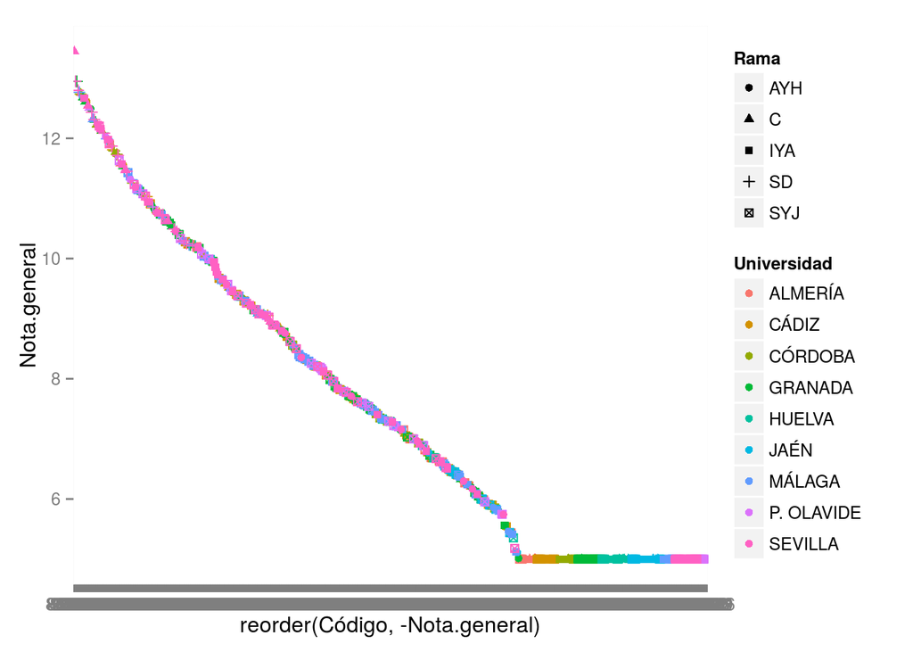

Ahora podemos trazar, por separado, cada una de las universidades, lo que nos muestra además el número de titulaciones por universidad, con Sevilla a la cabeza

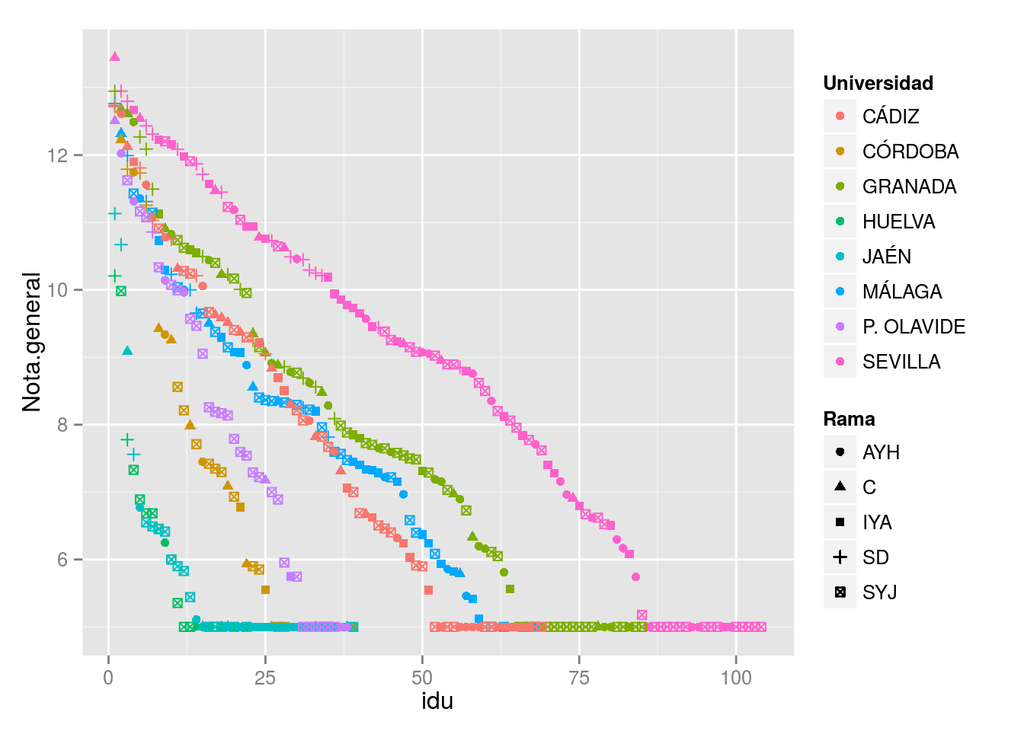

Este gráfico se puede normalizar dividiendo el puesto por el número de carreras, dando una idea también de qué porcentaje de grados en cada universidad no han cubierto el cupo de alumnos (aquellos con nota de corte igual a 5)

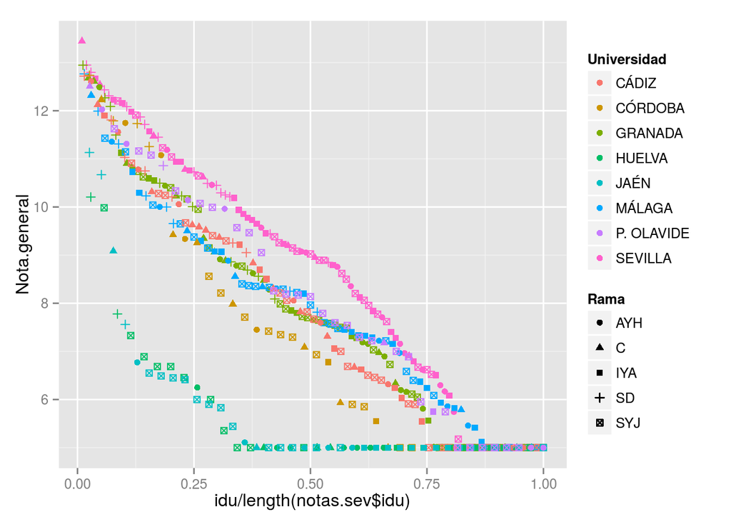

La media de nota de corte por universidad se presenta a continuación, en general revelando la demanda de las titulaciones y relacionada sobre todo con la población de la provincia, con la excepción de Cádiz

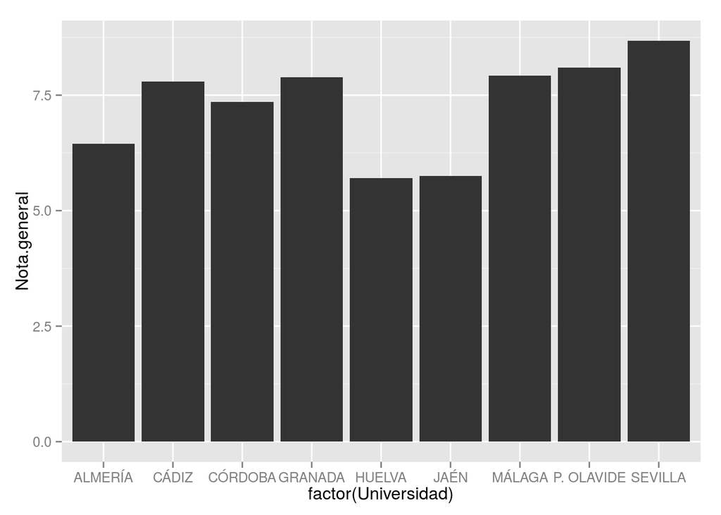

De la misma forma, la media por rama plasma la popularidad de las mismas, con las carreras saniarias especialmente populares y las de ingeniería y arquitectura en lo más bajo

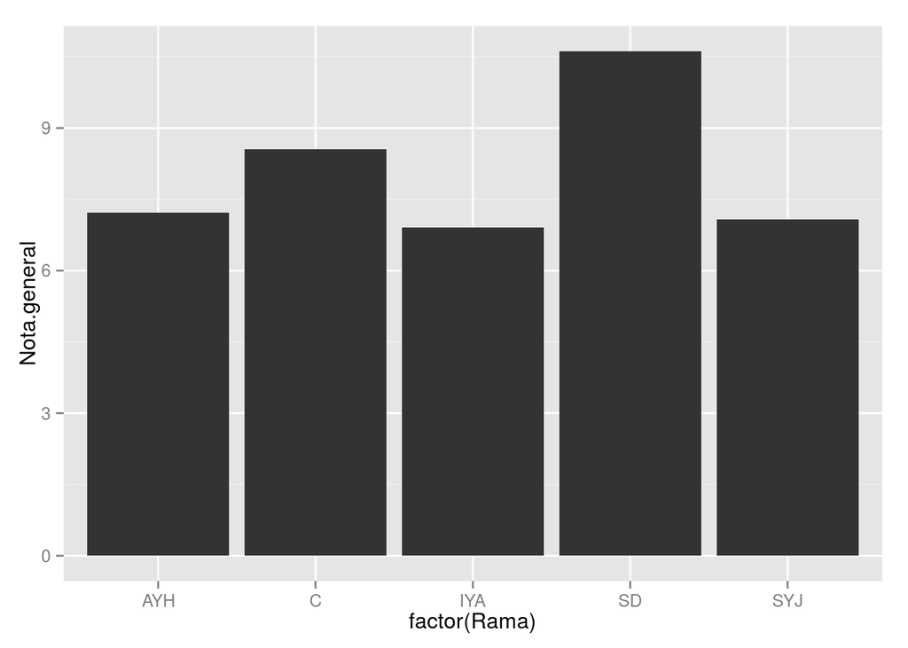

Finalmente, la media y mediana de notas para ingeniería y arquitectura, organizado por universidad

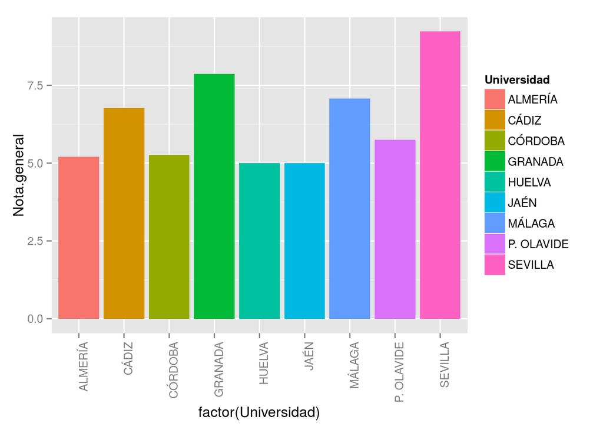

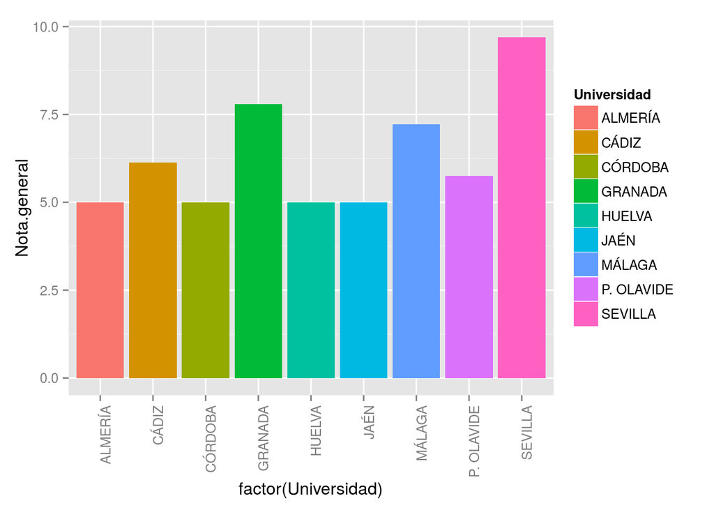

Y ahora comparando a igualdad de grados en las dos mayores universidades, Sevilla y Granada. Esta es una comparación de notas a igualdad de grados

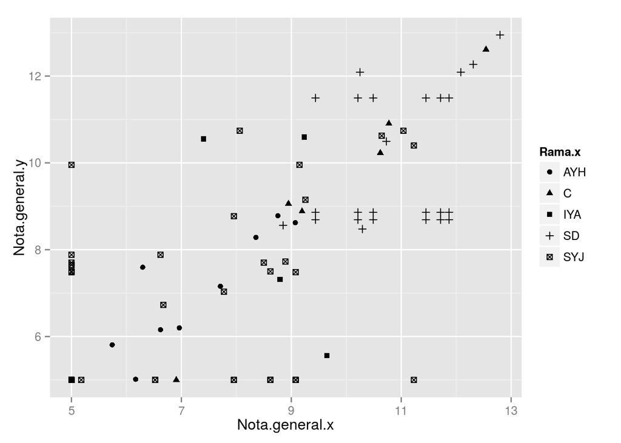

Finalmente, el porcentaje de carreras que tienen una nota de corte superior al 5 es equivalente a aquellas que han cubierto sus plazas. Su distribución por universidad es como sigue:

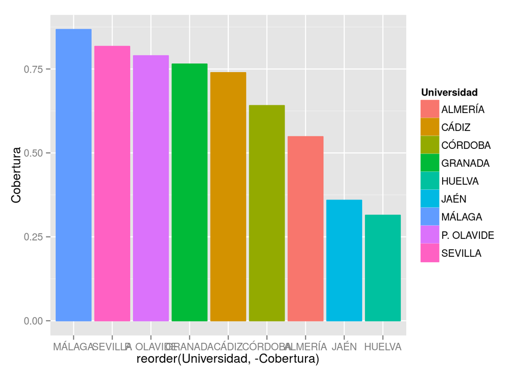

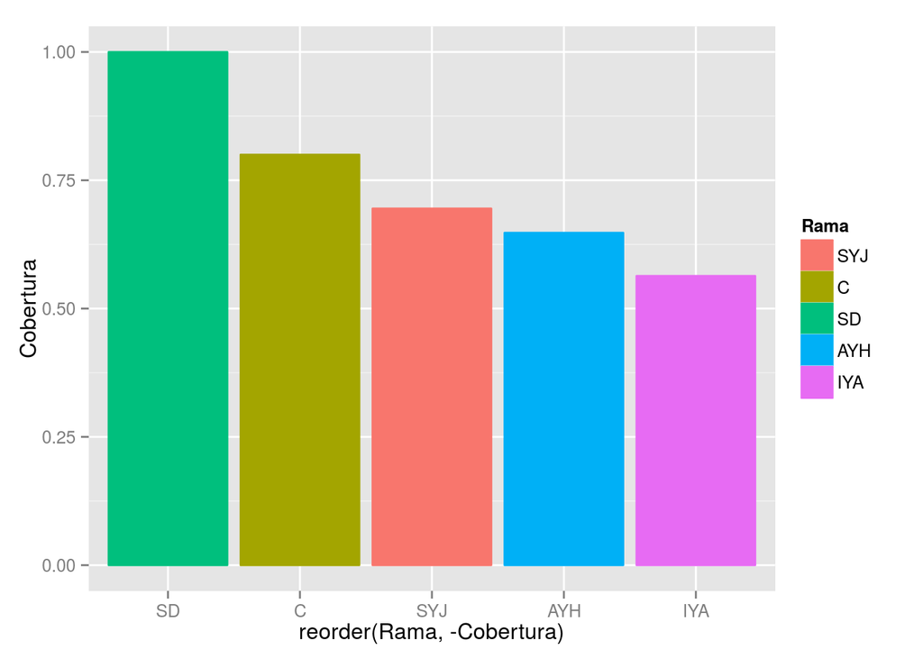